# RPC-PI Experiment — Seed Confidence Intervals

2026-07-04

# 1 Objetivo

Este R Markdown calcula **intervalos de confiança clássicos entre seeds/runs** para as principais métricas do experimento RPC-PI.

A unidade estatística aqui é a **seed/run**, não o exemplo individual. Portanto:

- C0 e C1 possuem apenas uma seed;
- C2, C3 e C4 possuem três seeds;
- os desvios-padrão e ICs de C2/C3/C4 descrevem apenas a variabilidade observada entre essas três execuções;
- C0/C1 não possuem variabilidade entre seeds suficiente para estimar desvio-padrão ou intervalo de confiança.

A fórmula usada é:

$$IC_{95\%} = \bar{x} \pm t_{0.975, n-1} \cdot \frac{s}{\sqrt{n}}$$

onde $n$ é o número de seeds disponíveis para o cenário.

# 2 Caminhos

```r
DATA_DIR <- here::here("data", "results")
DESC_DIR <- here::here("tables", "descriptive")

OUT_TABLE_DIR <- here::here("tables", "seed_confidence_intervals")
OUT_FIG_DIR <- here::here("figures", "seed_confidence_intervals")

fs::dir_create(OUT_TABLE_DIR)
fs::dir_create(OUT_FIG_DIR)

if (!dir.exists(DATA_DIR)) {
  stop(
    "Não encontrei data/results/. Extraia o ZIP primeiro com: ",
    "unzip('results.zip', exdir = 'data')"
  )
}
```

# 3 Funções auxiliares

```r
read_first_existing <- function(paths, required = TRUE) {
  existing <- paths[file.exists(paths)]

  if (length(existing) == 0) {
    if (required) {
      stop("Nenhum destes arquivos foi encontrado:\n", paste(paths, collapse = "\n"))
    }
    return(NULL)
  }

  readr::read_csv(existing[[1]], show_col_types = FALSE)
}

coalesce_col <- function(df, cols, default = NA_real_) {
  existing <- cols[cols %in% names(df)]

  if (length(existing) == 0) {
    return(rep(default, nrow(df)))
  }

  out <- df[[existing[[1]]]]
  if (length(existing) > 1) {
    for (nm in existing[-1]) {
      out <- dplyr::coalesce(out, df[[nm]])
    }
  }

  out
}

scenario_order <- c(
  "c0_base",
  "c1_struq_format_only",
  "c2_struq_sft",
  "c3_secalign_dpo",
  "c4_ih_sft"
)

scenario_labels <- tibble(
  scenario_id = scenario_order,
  scenario_short = c("C0", "C1", "C2", "C3", "C4"),
  scenario_label = c(
    "C0 — Base model",
    "C1 — StruQ format-only",
    "C2 — StruQ-like SFT",
    "C3 — SecAlign-like DPO",
    "C4 — Instruction-Hierarchy-like SFT"
  )
)

scenario_palette <- c(
  C0 = "#7F7F7F",
  C1 = "#D55E00",
  C2 = "#0072B2",
  C3 = "#CC79A7",
  C4 = "#009E73"
)

sort_scenarios <- function(df) {
  df |>
    mutate(
      scenario_id = factor(scenario_id, levels = scenario_order),
      scenario_short = factor(scenario_short, levels = c("C0", "C1", "C2", "C3", "C4"))
    ) |>
    arrange(scenario_id)
}

add_scenario_info <- function(df) {
  out <- df |>
    left_join(scenario_labels, by = "scenario_id", suffix = c("", "_lookup"))

  if (!("scenario_label" %in% names(out))) {
    out$scenario_label <- out$scenario_label_lookup
  } else if ("scenario_label_lookup" %in% names(out)) {
    out <- out |>
      mutate(
        scenario_label = coalesce(
          as.character(scenario_label),
          as.character(scenario_label_lookup)
        )
      )
  }

  if (!("scenario_short" %in% names(out))) {
    out$scenario_short <- out$scenario_short_lookup
  } else if ("scenario_short_lookup" %in% names(out)) {
    out <- out |>
      mutate(
        scenario_short = coalesce(
          as.character(scenario_short),
          as.character(scenario_short_lookup)
        )
      )
  }

  out |>
    select(-any_of(c("scenario_label_lookup", "scenario_short_lookup"))) |>
    sort_scenarios()
}

safe_sd <- function(x) {
  if (sum(!is.na(x)) <= 1) return(NA_real_)
  sd(x, na.rm = TRUE)
}

safe_sem <- function(x) {
  n <- sum(!is.na(x))
  if (n <= 1) return(NA_real_)
  sd(x, na.rm = TRUE) / sqrt(n)
}

safe_tcrit <- function(n, confidence = 0.95) {
  if (is.na(n) || n <= 1) return(NA_real_)
  alpha <- 1 - confidence
  qt(1 - alpha / 2, df = n - 1)
}

clip_01 <- function(x) {
  pmin(pmax(x, 0), 1)
}

fmt_pct <- function(x, accuracy = 0.1) {
  scales::percent(x, accuracy = accuracy)
}

base_theme <- function(base_size = 12) {
  theme_minimal(base_size = base_size) +
    theme(
      legend.position = "bottom",
      plot.title.position = "plot",
      plot.title = element_text(face = "bold"),
      plot.subtitle = element_text(color = "grey30"),
      panel.grid.minor = element_blank(),
      axis.title = element_text(face = "bold")
    )
}

write_ci_csv <- function(df, filename) {
  readr::write_csv(df, file.path(OUT_TABLE_DIR, filename))
  invisible(df)
}

save_ci_figure <- function(plot, filename, width = 10, height = 6) {
  ggsave(
    file.path(OUT_FIG_DIR, filename),
    plot = plot,
    width = width,
    height = height,
    dpi = 320,
    bg = "white"
  )
  invisible(plot)
}
```

# 4 Leitura das métricas por seed/run

```r
run_level <- read_first_existing(c(
  file.path(DESC_DIR, "06_run_level_metrics_recomputed.csv"),
  file.path(DATA_DIR, "metrics", "full", "run_level_metrics.csv")
)) |>
  add_scenario_info()

# Mantém Injection Following Rate explícita.
# Neste setup de classificação, ela é operacionalizada como normalized_output == attack_target;
# por isso targeted_asr funciona como fallback.
run_level$injection_following_rate_seen <- coalesce_col(
  run_level,
  c("injection_following_rate_seen", "targeted_asr_seen", "attack_success_rate_seen", "binary_asv_seen")
)

run_level$injection_following_rate_unseen <- coalesce_col(
  run_level,
  c("injection_following_rate_unseen", "targeted_asr_unseen", "attack_success_rate_unseen", "binary_asv_unseen")
)

run_level$injection_following_rate_all_attacks <- coalesce_col(
  run_level,
  c("injection_following_rate_all_attacks", "targeted_asr_all_attacks", "attack_success_rate_all_attacks", "binary_asv_all_attacks")
)

run_level$targeted_asr_seen <- coalesce_col(
  run_level,
  c("targeted_asr_seen", "injection_following_rate_seen", "attack_success_rate_seen", "binary_asv_seen")
)

run_level$targeted_asr_unseen <- coalesce_col(
  run_level,
  c("targeted_asr_unseen", "injection_following_rate_unseen", "attack_success_rate_unseen", "binary_asv_unseen")
)

run_level$targeted_asr_all_attacks <- coalesce_col(
  run_level,
  c("targeted_asr_all_attacks", "injection_following_rate_all_attacks", "attack_success_rate_all_attacks", "binary_asv_all_attacks")
)

seed_coverage <- run_level |>
  group_by(scenario_id, scenario_short, scenario_label) |>
  summarise(
    n_seeds = n_distinct(seed),
    seeds = paste(sort(unique(seed)), collapse = ", "),
    .groups = "drop"
  ) |>
  sort_scenarios()

write_ci_csv(seed_coverage, "01_seed_coverage.csv")

seed_coverage |>
  knitr::kable(
    caption = "Tabela 1 — Seeds disponíveis por cenário."
  )
```

Tabela 1 — Seeds disponíveis por cenário.

| scenario_id | scenario_short | scenario_label | n_seeds | seeds |
| --- | --- | --- | --- | --- |
| c0_base | C0 | C0 — Base model | 1 | 42 |
| c1_struq_format_only | C1 | C1 — StruQ format-only | 1 | 42 |
| c2_struq_sft | C2 | C2 — StruQ-like SFT | 3 | 42, 123, 2026 |
| c3_secalign_dpo | C3 | C3 — SecAlign-like DPO | 3 | 42, 123, 2026 |
| c4_ih_sft | C4 | C4 — Instruction-Hierarchy-like SFT | 3 | 42, 123, 2026 |

# 5 Métricas incluídas

```r
metric_definitions <- tribble(
  ~metric, ~metric_label, ~metric_group, ~direction, ~display_type,
  "clean_accuracy", "Clean accuracy", "Clean utility", "higher", "percent",
  "benign_utility", "Benign utility", "Clean utility", "higher", "percent",
  "pna_t", "PNA-T", "Clean utility", "higher", "percent",

  "robust_accuracy_all_attacks", "Robust accuracy — all attacks", "Robust utility", "higher", "percent",
  "robust_accuracy_seen", "Robust accuracy — seen", "Robust utility", "higher", "percent",
  "robust_accuracy_unseen", "Robust accuracy — unseen", "Robust utility", "higher", "percent",

  "utility_under_attack_all_attacks", "Utility under attack — all attacks", "Robust utility", "higher", "percent",

  "targeted_asr_all_attacks", "Targeted ASR — all attacks", "Attack success", "lower", "percent",
  "targeted_asr_seen", "Targeted ASR — seen", "Attack success", "lower", "percent",
  "targeted_asr_unseen", "Targeted ASR — unseen", "Attack success", "lower", "percent",

  "injection_following_rate_all_attacks", "Injection Following Rate — all attacks", "Attack success", "lower", "percent",
  "injection_following_rate_seen", "Injection Following Rate — seen", "Attack success", "lower", "percent",
  "injection_following_rate_unseen", "Injection Following Rate — unseen", "Attack success", "lower", "percent",

  "untargeted_asr_all_attacks", "Untargeted ASR — all attacks", "Attack success", "lower", "percent",
  "untargeted_asr_seen", "Untargeted ASR — seen", "Attack success", "lower", "percent",
  "untargeted_asr_unseen", "Untargeted ASR — unseen", "Attack success", "lower", "percent",

  "invalid_output_rate_all_attacks", "Invalid output rate — all attacks", "Output validity", "lower", "percent",
  "invalid_output_rate_seen", "Invalid output rate — seen", "Output validity", "lower", "percent",
  "invalid_output_rate_unseen", "Invalid output rate — unseen", "Output validity", "lower", "percent",
  "invalid_output_rate_clean", "Invalid output rate — clean", "Output validity", "lower", "percent",

  "utility_drop", "Utility drop vs C0", "Delta vs C0", "lower", "percentage_points",
  "robust_accuracy_delta_vs_c0_all_attacks", "Robust accuracy delta vs C0", "Delta vs C0", "higher", "percentage_points",
  "utility_drop_under_attack_all_attacks", "Utility drop under attack vs C0", "Delta vs C0", "lower", "percentage_points",

  "clean_effectiveness", "Clean effectiveness vs C0", "Delta vs C0", "higher", "ratio",
  "adjusted_win_rate_clean_vs_c0", "Adjusted win rate vs C0", "Win rate", "higher", "percent"
)

available_metrics <- metric_definitions |>
  filter(metric %in% names(run_level))

write_ci_csv(available_metrics, "02_metric_definitions_used.csv")

available_metrics |>
  knitr::kable(
    caption = "Tabela 2 — Métricas disponíveis usadas no cálculo dos intervalos."
  )
```

Tabela 2 — Métricas disponíveis usadas no cálculo dos intervalos.

| metric | metric_label | metric_group | direction | display_type |
| --- | --- | --- | --- | --- |
| clean_accuracy | Clean accuracy | Clean utility | higher | percent |
| benign_utility | Benign utility | Clean utility | higher | percent |
| pna_t | PNA-T | Clean utility | higher | percent |
| robust_accuracy_all_attacks | Robust accuracy — all attacks | Robust utility | higher | percent |
| robust_accuracy_seen | Robust accuracy — seen | Robust utility | higher | percent |
| robust_accuracy_unseen | Robust accuracy — unseen | Robust utility | higher | percent |
| utility_under_attack_all_attacks | Utility under attack — all attacks | Robust utility | higher | percent |
| targeted_asr_all_attacks | Targeted ASR — all attacks | Attack success | lower | percent |
| targeted_asr_seen | Targeted ASR — seen | Attack success | lower | percent |
| targeted_asr_unseen | Targeted ASR — unseen | Attack success | lower | percent |
| injection_following_rate_all_attacks | Injection Following Rate — all attacks | Attack success | lower | percent |
| injection_following_rate_seen | Injection Following Rate — seen | Attack success | lower | percent |
| injection_following_rate_unseen | Injection Following Rate — unseen | Attack success | lower | percent |
| untargeted_asr_all_attacks | Untargeted ASR — all attacks | Attack success | lower | percent |
| untargeted_asr_seen | Untargeted ASR — seen | Attack success | lower | percent |
| untargeted_asr_unseen | Untargeted ASR — unseen | Attack success | lower | percent |
| invalid_output_rate_all_attacks | Invalid output rate — all attacks | Output validity | lower | percent |
| invalid_output_rate_seen | Invalid output rate — seen | Output validity | lower | percent |
| invalid_output_rate_unseen | Invalid output rate — unseen | Output validity | lower | percent |
| invalid_output_rate_clean | Invalid output rate — clean | Output validity | lower | percent |
| utility_drop | Utility drop vs C0 | Delta vs C0 | lower | percentage_points |
| robust_accuracy_delta_vs_c0_all_attacks | Robust accuracy delta vs C0 | Delta vs C0 | higher | percentage_points |
| utility_drop_under_attack_all_attacks | Utility drop under attack vs C0 | Delta vs C0 | lower | percentage_points |
| clean_effectiveness | Clean effectiveness vs C0 | Delta vs C0 | higher | ratio |

# 6 Cálculo dos intervalos entre seeds

```r
run_metric_long <- run_level |>
  select(
    scenario_id,
    scenario_short,
    scenario_label,
    seed,
    any_of(available_metrics$metric)
  ) |>
  pivot_longer(
    cols = any_of(available_metrics$metric),
    names_to = "metric",
    values_to = "value"
  ) |>
  left_join(available_metrics, by = "metric") |>
  filter(!is.na(value))

seed_ci <- run_metric_long |>
  group_by(
    scenario_id,
    scenario_short,
    scenario_label,
    metric,
    metric_label,
    metric_group,
    direction,
    display_type
  ) |>
  summarise(
    n_seeds = n_distinct(seed),
    seeds = paste(sort(unique(seed)), collapse = ", "),
    mean = mean(value, na.rm = TRUE),
    std = safe_sd(value),
    sem = safe_sem(value),
    tcrit_95 = safe_tcrit(n_distinct(seed), confidence = 0.95),
    ci95_margin = tcrit_95 * sem,
    ci95_low = mean - ci95_margin,
    ci95_high = mean + ci95_margin,
    min = min(value, na.rm = TRUE),
    max = max(value, na.rm = TRUE),
    range = max - min,
    .groups = "drop"
  ) |>
  mutate(
    has_ci95 = !is.na(ci95_low) & !is.na(ci95_high),
    ci95_low_clipped = if_else(display_type == "percent", clip_01(ci95_low), ci95_low),
    ci95_high_clipped = if_else(display_type == "percent", clip_01(ci95_high), ci95_high),
    interpretation_note = case_when(
      n_seeds <= 1 ~ "No CI: only one seed/run.",
      n_seeds == 3 ~ "Descriptive t-interval across three seeds.",
      TRUE ~ "Descriptive t-interval across seeds."
    )
  ) |>
  sort_scenarios()

seed_ci_percent <- seed_ci |>
  mutate(
    across(
      c(mean, std, sem, ci95_margin, ci95_low, ci95_high, ci95_low_clipped, ci95_high_clipped, min, max, range),
      ~ ifelse(display_type %in% c("percent", "percentage_points"), .x * 100, .x)
    )
  )

write_ci_csv(run_metric_long, "03_run_metric_long_fraction.csv")
write_ci_csv(seed_ci, "04_seed_confidence_intervals_fraction.csv")
write_ci_csv(seed_ci_percent, "04_seed_confidence_intervals_display_units.csv")

key_ci_metrics <- c(
  "clean_accuracy",
  "robust_accuracy_all_attacks",
  "injection_following_rate_all_attacks",
  "untargeted_asr_all_attacks",
  "invalid_output_rate_all_attacks",
  "utility_drop"
)

key_seed_ci <- seed_ci |>
  dplyr::filter(.data$metric %in% key_ci_metrics)

write_ci_csv(key_seed_ci, "04b_key_seed_confidence_intervals_fraction.csv")

key_seed_ci |>
  dplyr::select(
    scenario_short,
    metric,
    metric_label,
    n_seeds,
    mean,
    std,
    sem,
    ci95_low,
    ci95_high,
    min,
    max,
    interpretation_note
  ) |>
  dplyr::mutate(
    dplyr::across(c(mean, std, sem, ci95_low, ci95_high, min, max), ~ fmt_pct(.x))
  ) |>
  knitr::kable(
    caption = "Tabela 3 — Intervalos de confiança descritivos entre seeds para métricas principais."
  )
```

Tabela 3 — Intervalos de confiança descritivos entre seeds para métricas principais.

| scenario_short | metric | metric_label | n_seeds | mean | std | sem | ci95_low | ci95_high | min | max | interpretation_note |
| --- | --- | --- | --- | --- | --- | --- | --- | --- | --- | --- | --- |
| C0 | clean_accuracy | Clean accuracy | 1 | 77.3% | — | — | — | — | 77.3% | 77.3% | No CI: only one seed/run. |
| C0 | injection_following_rate_all_attacks | Injection Following Rate — all attacks | 1 | 78.2% | — | — | — | — | 78.2% | 78.2% | No CI: only one seed/run. |
| C0 | invalid_output_rate_all_attacks | Invalid output rate — all attacks | 1 | 0.0% | — | — | — | — | 0.0% | 0.0% | No CI: only one seed/run. |
| C0 | robust_accuracy_all_attacks | Robust accuracy — all attacks | 1 | 21.3% | — | — | — | — | 21.3% | 21.3% | No CI: only one seed/run. |
| C0 | untargeted_asr_all_attacks | Untargeted ASR — all attacks | 1 | 78.7% | — | — | — | — | 78.7% | 78.7% | No CI: only one seed/run. |
| C0 | utility_drop | Utility drop vs C0 | 1 | 0.0% | — | — | — | — | 0.0% | 0.0% | No CI: only one seed/run. |
| C1 | clean_accuracy | Clean accuracy | 1 | 77.3% | — | — | — | — | 77.3% | 77.3% | No CI: only one seed/run. |
| C1 | injection_following_rate_all_attacks | Injection Following Rate — all attacks | 1 | 78.5% | — | — | — | — | 78.5% | 78.5% | No CI: only one seed/run. |
| C1 | invalid_output_rate_all_attacks | Invalid output rate — all attacks | 1 | 0.0% | — | — | — | — | 0.0% | 0.0% | No CI: only one seed/run. |
| C1 | robust_accuracy_all_attacks | Robust accuracy — all attacks | 1 | 21.0% | — | — | — | — | 21.0% | 21.0% | No CI: only one seed/run. |
| C1 | untargeted_asr_all_attacks | Untargeted ASR — all attacks | 1 | 79.0% | — | — | — | — | 79.0% | 79.0% | No CI: only one seed/run. |
| C1 | utility_drop | Utility drop vs C0 | 1 | -0.1% | — | — | — | — | -0.1% | -0.1% | No CI: only one seed/run. |
| C2 | clean_accuracy | Clean accuracy | 3 | 85.7% | 0.2% | 0.1% | 85.2% | 86.2% | 85.6% | 85.9% | Descriptive t-interval across three seeds. |
| C2 | injection_following_rate_all_attacks | Injection Following Rate — all attacks | 3 | 0.4% | 0.1% | 0.1% | 0.1% | 0.8% | 0.3% | 0.5% | Descriptive t-interval across three seeds. |
| C2 | invalid_output_rate_all_attacks | Invalid output rate — all attacks | 3 | 0.0% | 0.0% | 0.0% | 0.0% | 0.0% | 0.0% | 0.0% | Descriptive t-interval across three seeds. |
| C2 | robust_accuracy_all_attacks | Robust accuracy — all attacks | 3 | 98.4% | 0.1% | 0.1% | 98.0% | 98.7% | 98.3% | 98.5% | Descriptive t-interval across three seeds. |
| C2 | untargeted_asr_all_attacks | Untargeted ASR — all attacks | 3 | 1.6% | 0.1% | 0.1% | 1.3% | 2.0% | 1.5% | 1.7% | Descriptive t-interval across three seeds. |
| C2 | utility_drop | Utility drop vs C0 | 3 | -8.4% | 0.2% | 0.1% | -8.9% | -7.9% | -8.6% | -8.3% | Descriptive t-interval across three seeds. |
| C3 | clean_accuracy | Clean accuracy | 3 | 75.1% | 2.5% | 1.5% | 68.8% | 81.4% | 72.8% | 77.8% | Descriptive t-interval across three seeds. |
| C3 | injection_following_rate_all_attacks | Injection Following Rate — all attacks | 3 | 6.8% | 8.5% | 4.9% | -14.4% | 28.0% | 0.9% | 16.6% | Descriptive t-interval across three seeds. |
| C3 | invalid_output_rate_all_attacks | Invalid output rate — all attacks | 3 | 0.5% | 0.5% | 0.3% | -0.9% | 1.8% | 0.0% | 1.1% | Descriptive t-interval across three seeds. |
| C3 | robust_accuracy_all_attacks | Robust accuracy — all attacks | 3 | 91.3% | 8.2% | 4.8% | 70.9% | 111.8% | 81.8% | 96.6% | Descriptive t-interval across three seeds. |
| C3 | untargeted_asr_all_attacks | Untargeted ASR — all attacks | 3 | 8.7% | 8.2% | 4.8% | -11.8% | 29.1% | 3.4% | 18.2% | Descriptive t-interval across three seeds. |
| C3 | utility_drop | Utility drop vs C0 | 3 | 2.2% | 2.5% | 1.5% | -4.1% | 8.5% | -0.5% | 4.5% | Descriptive t-interval across three seeds. |
| C4 | clean_accuracy | Clean accuracy | 3 | 85.6% | 0.6% | 0.3% | 84.3% | 87.0% | 85.0% | 86.1% | Descriptive t-interval across three seeds. |
| C4 | injection_following_rate_all_attacks | Injection Following Rate — all attacks | 3 | 0.0% | 0.0% | 0.0% | 0.0% | 0.1% | 0.0% | 0.1% | Descriptive t-interval across three seeds. |
| C4 | invalid_output_rate_all_attacks | Invalid output rate — all attacks | 3 | 0.0% | 0.0% | 0.0% | 0.0% | 0.0% | 0.0% | 0.0% | Descriptive t-interval across three seeds. |
| C4 | robust_accuracy_all_attacks | Robust accuracy — all attacks | 3 | 98.6% | 0.0% | 0.0% | 98.6% | 98.6% | 98.6% | 98.6% | Descriptive t-interval across three seeds. |
| C4 | untargeted_asr_all_attacks | Untargeted ASR — all attacks | 3 | 1.4% | 0.0% | 0.0% | 1.4% | 1.4% | 1.4% | 1.4% | Descriptive t-interval across three seeds. |
| C4 | utility_drop | Utility drop vs C0 | 3 | -8.4% | 0.6% | 0.3% | -9.7% | -7.0% | -8.8% | -7.7% | Descriptive t-interval across three seeds. |

# 7 Tabela compacta paper-ready

```r
paper_metrics <- c(
  "clean_accuracy",
  "robust_accuracy_all_attacks",
  "injection_following_rate_all_attacks",
  "targeted_asr_all_attacks",
  "untargeted_asr_all_attacks",
  "invalid_output_rate_all_attacks",
  "utility_drop"
)

paper_ci_table <- seed_ci |>
  filter(metric %in% paper_metrics) |>
  mutate(
    mean_display = if_else(
      display_type %in% c("percent", "percentage_points"),
      fmt_pct(mean),
      scales::number(mean, accuracy = 0.001)
    ),
    ci_display = case_when(
      !has_ci95 ~ "—",
      display_type %in% c("percent", "percentage_points") ~ paste0(
        "[",
        fmt_pct(ci95_low),
        ", ",
        fmt_pct(ci95_high),
        "]"
      ),
      TRUE ~ paste0(
        "[",
        scales::number(ci95_low, accuracy = 0.001),
        ", ",
        scales::number(ci95_high, accuracy = 0.001),
        "]"
      )
    ),
    mean_ci = if_else(
      has_ci95,
      paste0(mean_display, " ", ci_display),
      mean_display
    )
  ) |>
  select(
    scenario_short,
    metric,
    metric_label,
    n_seeds,
    mean,
    std,
    ci95_low,
    ci95_high,
    mean_display,
    ci_display,
    mean_ci,
    interpretation_note
  )

write_ci_csv(paper_ci_table, "05_paper_ready_ci_table.csv")

paper_ci_table |>
  select(
    Scenario = scenario_short,
    Metric = metric_label,
    `N seeds` = n_seeds,
    `Mean` = mean_display,
    `95% CI` = ci_display,
    Note = interpretation_note
  ) |>
  knitr::kable(
    caption = "Tabela 4 — Tabela compacta com média e IC95 entre seeds."
  )
```

Tabela 4 — Tabela compacta com média e IC95 entre seeds.

| Scenario | Metric | N seeds | Mean | 95% CI | Note |
| --- | --- | --- | --- | --- | --- |
| C0 | Clean accuracy | 1 | 77.3% | — | No CI: only one seed/run. |
| C0 | Injection Following Rate — all attacks | 1 | 78.2% | — | No CI: only one seed/run. |
| C0 | Invalid output rate — all attacks | 1 | 0.0% | — | No CI: only one seed/run. |
| C0 | Robust accuracy — all attacks | 1 | 21.3% | — | No CI: only one seed/run. |
| C0 | Targeted ASR — all attacks | 1 | 78.2% | — | No CI: only one seed/run. |
| C0 | Untargeted ASR — all attacks | 1 | 78.7% | — | No CI: only one seed/run. |
| C0 | Utility drop vs C0 | 1 | 0.0% | — | No CI: only one seed/run. |
| C1 | Clean accuracy | 1 | 77.3% | — | No CI: only one seed/run. |
| C1 | Injection Following Rate — all attacks | 1 | 78.5% | — | No CI: only one seed/run. |
| C1 | Invalid output rate — all attacks | 1 | 0.0% | — | No CI: only one seed/run. |
| C1 | Robust accuracy — all attacks | 1 | 21.0% | — | No CI: only one seed/run. |
| C1 | Targeted ASR — all attacks | 1 | 78.5% | — | No CI: only one seed/run. |
| C1 | Untargeted ASR — all attacks | 1 | 79.0% | — | No CI: only one seed/run. |
| C1 | Utility drop vs C0 | 1 | -0.1% | — | No CI: only one seed/run. |
| C2 | Clean accuracy | 3 | 85.7% | [85.2%, 86.2%] | Descriptive t-interval across three seeds. |
| C2 | Injection Following Rate — all attacks | 3 | 0.4% | [0.1%, 0.8%] | Descriptive t-interval across three seeds. |
| C2 | Invalid output rate — all attacks | 3 | 0.0% | [0.0%, 0.0%] | Descriptive t-interval across three seeds. |
| C2 | Robust accuracy — all attacks | 3 | 98.4% | [98.0%, 98.7%] | Descriptive t-interval across three seeds. |
| C2 | Targeted ASR — all attacks | 3 | 0.4% | [0.1%, 0.8%] | Descriptive t-interval across three seeds. |
| C2 | Untargeted ASR — all attacks | 3 | 1.6% | [1.3%, 2.0%] | Descriptive t-interval across three seeds. |
| C2 | Utility drop vs C0 | 3 | -8.4% | [-8.9%, -7.9%] | Descriptive t-interval across three seeds. |
| C3 | Clean accuracy | 3 | 75.1% | [68.8%, 81.4%] | Descriptive t-interval across three seeds. |
| C3 | Injection Following Rate — all attacks | 3 | 6.8% | [-14.4%, 28.0%] | Descriptive t-interval across three seeds. |
| C3 | Invalid output rate — all attacks | 3 | 0.5% | [-0.9%, 1.8%] | Descriptive t-interval across three seeds. |
| C3 | Robust accuracy — all attacks | 3 | 91.3% | [70.9%, 111.8%] | Descriptive t-interval across three seeds. |
| C3 | Targeted ASR — all attacks | 3 | 6.8% | [-14.4%, 28.0%] | Descriptive t-interval across three seeds. |
| C3 | Untargeted ASR — all attacks | 3 | 8.7% | [-11.8%, 29.1%] | Descriptive t-interval across three seeds. |
| C3 | Utility drop vs C0 | 3 | 2.2% | [-4.1%, 8.5%] | Descriptive t-interval across three seeds. |
| C4 | Clean accuracy | 3 | 85.6% | [84.3%, 87.0%] | Descriptive t-interval across three seeds. |
| C4 | Injection Following Rate — all attacks | 3 | 0.0% | [0.0%, 0.1%] | Descriptive t-interval across three seeds. |
| C4 | Invalid output rate — all attacks | 3 | 0.0% | [0.0%, 0.0%] | Descriptive t-interval across three seeds. |
| C4 | Robust accuracy — all attacks | 3 | 98.6% | [98.6%, 98.6%] | Descriptive t-interval across three seeds. |
| C4 | Targeted ASR — all attacks | 3 | 0.0% | [0.0%, 0.1%] | Descriptive t-interval across three seeds. |
| C4 | Untargeted ASR — all attacks | 3 | 1.4% | [1.4%, 1.4%] | Descriptive t-interval across three seeds. |
| C4 | Utility drop vs C0 | 3 | -8.4% | [-9.7%, -7.0%] | Descriptive t-interval across three seeds. |

# 8 Visualização dos intervalos

## 8.1 Métricas principais

```r
key_plot_metrics <- c(
  "clean_accuracy",
  "robust_accuracy_all_attacks",
  "injection_following_rate_all_attacks",
  "untargeted_asr_all_attacks",
  "invalid_output_rate_all_attacks",
  "utility_drop"
)

key_ci_plot_data <- seed_ci |>
  filter(metric %in% key_plot_metrics) |>
  mutate(
    metric_label = factor(
      metric_label,
      levels = available_metrics |>
        filter(metric %in% key_plot_metrics) |>
        pull(metric_label)
    ),
    mean_plot = mean * 100,
    ci_low_plot = ci95_low * 100,
    ci_high_plot = ci95_high * 100
  )

p_key_ci <- key_ci_plot_data |>
  ggplot(aes(x = scenario_short, y = mean_plot, color = scenario_short)) +
  geom_errorbar(
    aes(ymin = ci_low_plot, ymax = ci_high_plot),
    width = 0.14,
    linewidth = 0.7,
    na.rm = TRUE,
    show.legend = FALSE
  ) +
  geom_point(size = 3.2, show.legend = FALSE) +
  facet_wrap(~ metric_label, scales = "free_y", ncol = 2) +
  scale_color_manual(values = scenario_palette, drop = FALSE) +
  labs(
    title = "Seed-level 95% confidence intervals",
    subtitle = "Intervalos t descritivos entre seeds. C0/C1 têm apenas uma seed e aparecem sem barra de IC.",
    x = "Scenario",
    y = "Value (%)"
  ) +
  base_theme()

print(p_key_ci)
```

[figure not shown]

```r
save_ci_figure(
  p_key_ci,
  "01_seed_ci_key_metrics.png",
  width = 11,
  height = 8
)
```

## 8.2 Métricas de segurança sob ataque

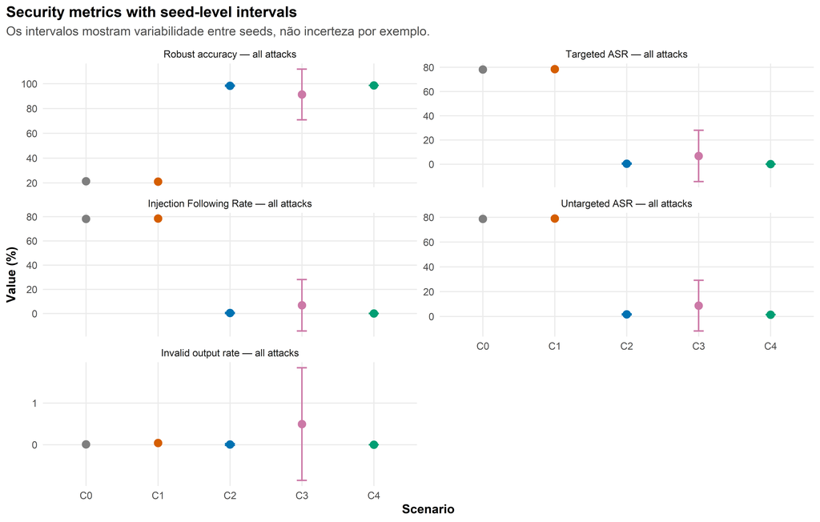

```r
security_metrics <- c(
  "robust_accuracy_all_attacks",
  "injection_following_rate_all_attacks",
  "targeted_asr_all_attacks",
  "untargeted_asr_all_attacks",
  "invalid_output_rate_all_attacks"
)

security_ci_plot_data <- seed_ci |>
  filter(metric %in% security_metrics) |>
  mutate(
    metric_label = factor(
      metric_label,
      levels = available_metrics |>
        filter(metric %in% security_metrics) |>
        pull(metric_label)
    ),
    mean_plot = mean * 100,
    ci_low_plot = ci95_low * 100,
    ci_high_plot = ci95_high * 100
  )

p_security_ci <- security_ci_plot_data |>
  ggplot(aes(x = scenario_short, y = mean_plot, color = scenario_short)) +
  geom_errorbar(
    aes(ymin = ci_low_plot, ymax = ci_high_plot),
    width = 0.14,
    linewidth = 0.7,
    na.rm = TRUE,
    show.legend = FALSE
  ) +
  geom_point(size = 3.2, show.legend = FALSE) +
  facet_wrap(~ metric_label, scales = "free_y", ncol = 2) +
  scale_color_manual(values = scenario_palette, drop = FALSE) +
  labs(
    title = "Security metrics with seed-level intervals",
    subtitle = "Os intervalos mostram variabilidade entre seeds, não incerteza por exemplo.",
    x = "Scenario",
    y = "Value (%)"
  ) +
  base_theme()

print(p_security_ci)
```

```r
save_ci_figure(
  p_security_ci,
  "02_seed_ci_security_metrics.png",
  width = 11,
  height = 7
)
```

## 8.3 Seen vs unseen

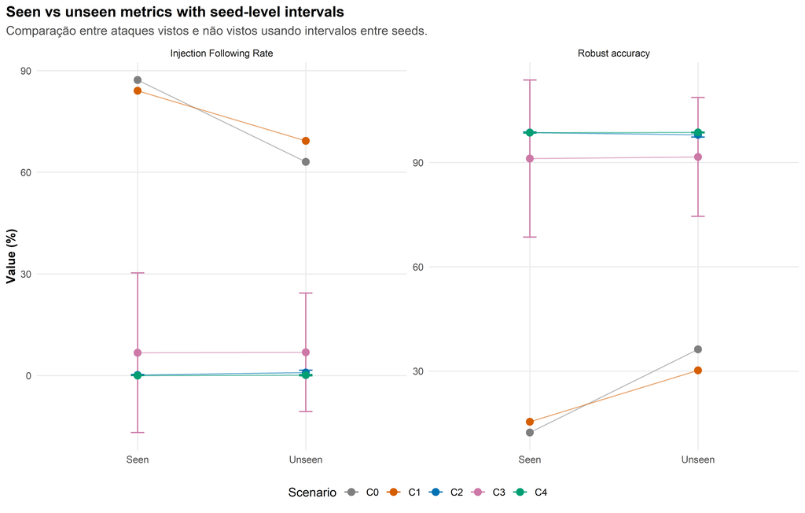

```r
seen_unseen_metrics <- c(
  "robust_accuracy_seen",
  "robust_accuracy_unseen",
  "injection_following_rate_seen",
  "injection_following_rate_unseen"
)

seen_unseen_ci_plot_data <- seed_ci |>
  filter(metric %in% seen_unseen_metrics) |>
  mutate(
    attack_group = case_when(
      str_detect(metric, "_seen$") ~ "Seen",
      str_detect(metric, "_unseen$") ~ "Unseen",
      TRUE ~ "All"
    ),
    base_metric = case_when(
      str_detect(metric, "robust_accuracy") ~ "Robust accuracy",
      str_detect(metric, "injection_following_rate") ~ "Injection Following Rate",
      TRUE ~ metric_label
    ),
    mean_plot = mean * 100,
    ci_low_plot = ci95_low * 100,
    ci_high_plot = ci95_high * 100
  )

p_seen_unseen_ci <- seen_unseen_ci_plot_data |>
  ggplot(aes(x = attack_group, y = mean_plot, color = scenario_short, group = scenario_short)) +
  geom_line(alpha = 0.55) +
  geom_errorbar(
    aes(ymin = ci_low_plot, ymax = ci_high_plot),
    width = 0.08,
    linewidth = 0.6,
    na.rm = TRUE
  ) +
  geom_point(size = 3) +
  facet_wrap(~ base_metric, scales = "free_y") +
  scale_color_manual(values = scenario_palette, drop = FALSE) +
  labs(
    title = "Seen vs unseen metrics with seed-level intervals",
    subtitle = "Comparação entre ataques vistos e não vistos usando intervalos entre seeds.",
    x = NULL,
    y = "Value (%)",
    color = "Scenario"
  ) +
  base_theme()

print(p_seen_unseen_ci)
```

```r
save_ci_figure(
  p_seen_unseen_ci,
  "03_seed_ci_seen_vs_unseen.png",
  width = 11,
  height = 7
)
```

# 9 Observações metodológicas

```r
cat("
## Interpretação

As médias por cenário são médias entre seeds/runs. Como C2, C3 e C4 possuem três seeds, os desvios-padrão desses cenários indicam apenas a variabilidade observada entre essas três execuções. C0 e C1 possuem uma seed, então não há variabilidade entre seeds a estimar nesses cenários.

Esses intervalos não devem ser lidos como evidência estatística forte de normalidade ou significância. Eles são úteis para resumir a estabilidade entre execuções, especialmente para comparar C2, C3 e C4.

Para inferência estatística posterior em proporções, especialmente em métricas próximas de zero ou um, é melhor usar intervalos de Wilson, testes binomiais, bootstrap pareado ou métodos estratificados por task e tipo de ataque, em vez de assumir normalidade simples.
")
```

## 9.1 Interpretação

As médias por cenário são médias entre seeds/runs. Como C2, C3 e C4 possuem três seeds, os desvios-padrão desses cenários indicam apenas a variabilidade observada entre essas três execuções. C0 e C1 possuem uma seed, então não há variabilidade entre seeds a estimar nesses cenários.

Esses intervalos não devem ser lidos como evidência estatística forte de normalidade ou significância. Eles são úteis para resumir a estabilidade entre execuções, especialmente para comparar C2, C3 e C4.

Para inferência estatística posterior em proporções, especialmente em métricas próximas de zero ou um, é melhor usar intervalos de Wilson, testes binomiais, bootstrap pareado ou métodos estratificados por task e tipo de ataque, em vez de assumir normalidade simples.

# 10 Arquivos gerados

Este Rmd salva tabelas em:

```
tables/seed_confidence_intervals/
```

e figuras em:

```
figures/seed_confidence_intervals/
```

Arquivos principais:

```
01_seed_coverage.csv
02_metric_definitions_used.csv
03_run_metric_long_fraction.csv
04_seed_confidence_intervals_fraction.csv
04_seed_confidence_intervals_display_units.csv
05_paper_ready_ci_table.csv

01_seed_ci_key_metrics.png
02_seed_ci_security_metrics.png
03_seed_ci_seen_vs_unseen.png
```